# Biostat 212a Homework 1

Due Jan 28, 2025 @ 11:59PM

Author

Nathaniel Boyle and 006525153

Published

January 27, 2025

## 1 Filling gaps in lecture notes (10% pts)

Consider the regression model
$$Y = f(X) + \epsilon,$$
where $\operatorname{E}(\epsilon) = 0$.

### 1.1 Optimal regression function

Show that the choice
$$f_{\text{opt}}(X) = \operatorname{E}(Y | X)$$
minimizes the mean squared prediction error
$$\operatorname{E}\{[Y - f(X)]^2\},$$
where the expectations averages over variations in both $X$ and $Y$. (Hint: condition on $X$.)

### 1.2 Define the Mean Squared Prediction Error

The mean squared prediction error is given by:

$$\operatorname{E}\{[Y - f(X)]^2\}.$$

Expand the squared term inside the expectation:

$$\operatorname{E}\{[Y - f(X)]^2\} = \operatorname{E}\left\{ Y^2 - 2Y f(X) + f(X)^2 \right\}.$$

Operator is linear, separate the terms:

$$\operatorname{E}\{[Y - f(X)]^2\} = \operatorname{E}(Y^2) - 2 f(X) \operatorname{E}(Y) + f(X)^2.$$

$$\operatorname{E}\left\{ [Y - f(X)]^2 \Big| X \right\}.$$

### 1.3 Minimize the Conditional Expectation

The conditional expectation:

$$\operatorname{E}\left\{ [Y - f(X)]^2 \Big| X \right\} = \operatorname{E}\left\{ Y^2 - 2Y f(X) + f(X)^2 \Big| X \right\}.$$

Using the properties of conditional expectation, we can break this up:

$$\operatorname{E}\left\{ Y^2 - 2Y f(X) + f(X)^2 \Big| X \right\} = \operatorname{E}(Y^2 | X) - 2 f(X) \operatorname{E}(Y | X) + f(X)^2.$$

### 1.4 Minimize with Respect to $f(X)$

Take the derivative of the conditional expectation with respect to $f(X)$:

$$\frac{d}{df(X)} \left( \operatorname{E}(Y^2 | X) - 2 f(X) \operatorname{E}(Y | X) + f(X)^2 \right) = - 2 \operatorname{E}(Y | X) + 2 f(X).$$
Set this derivative equal to zero to find the critical point:

$$- 2 \operatorname{E}(Y | X) + 2 f(X) = 0.$$
This simplifies to:

$$f(X) = \operatorname{E}(Y | X).$$
Therefore, the function $f(X) = \operatorname{E}(Y | X)$ minimizes the mean squared prediction error $\operatorname{E}\{[Y - f(X)]^2\}$.

### 1.5 Bias-variance trade-off

Given an estimate $\hat f$ of $f$, show that the test error at a $x_0$ can be decomposed as
$$\operatorname{E}\{[y_0 - \hat f(x_0)]^2\} = \underbrace{\operatorname{Var}(\hat f(x_0)) + [\operatorname{Bias}(\hat f(x_0))]^2}_{\text{MSE of } \hat f(x_0) \text{ for estimating } f(x_0)} + \underbrace{\operatorname{Var}(\epsilon)}_{\text{irreducible}},$$
where the expectation averages over the variability in $y_0$ and $\hat f$.

### 1.6 The Regression Model

The regression model is given by:

$$y_0 = f(x_0) + \epsilon_0,$$

where $f(x_0)$ is the true function value at $x_0$, and $\epsilon_0$ is the error term associated with the observation $y_0$. We assume that $\epsilon_0$ has zero mean and variance $\operatorname{Var}(\epsilon_0)$.

The estimate of $f(x_0)$ based on some estimator $\hat f(x_0)$ is an approximation to the true function $f(x_0)$. The test error is the squared difference between the true value $y_0$ and the estimate $\hat f(x_0)$:

$$\operatorname{E}\{[y_0 - \hat f(x_0)]^2\}.$$

### 1.7 Expand the Test Error

Expanding the squared difference:

$$\operatorname{E}\{[y_0 - \hat f(x_0)]^2\} = \operatorname{E}\{(y_0 - f(x_0) + f(x_0) - \hat f(x_0))^2\}.$$

This expands to:

$$\operatorname{E}\{[y_0 - f(x_0)]^2\} + \operatorname{E}\{[\hat f(x_0) - f(x_0)]^2\} + 2 \operatorname{E}\{(y_0 - f(x_0))(\hat f(x_0) - f(x_0))\}.$$

### 1.8 Simplify Each Term

1. **First term: $\operatorname{E}\{[y_0 - f(x_0)]^2\}$**

   Since $y_0 = f(x_0) + \epsilon_0$, we have:

   $$\operatorname{E}\{[y_0 - f(x_0)]^2\} = \operatorname{E}\{\epsilon_0^2\} = \operatorname{Var}(\epsilon_0).$$

   This is the **irreducible error**.
2. **Second term: $\operatorname{E}\{[\hat f(x_0) - f(x_0)]^2\}$**

   This term represents the **mean squared error (MSE)** of the estimator $\hat f(x_0)$ at $x_0$. It can be decomposed as:

   $$\operatorname{E}\{[\hat f(x_0) - f(x_0)]^2\} = \operatorname{Var}(\hat f(x_0)) + [\operatorname{Bias}(\hat f(x_0))]^2,$$
3. **Third term: $2 \operatorname{E}\{(y_0 - f(x_0))(\hat f(x_0) - f(x_0))\}$**

   Since $y_0 - f(x_0) = \epsilon_0$, this term becomes:

   $$2 \operatorname{E}\{\epsilon_0 (\hat f(x_0) - f(x_0))\}.$$

   Assuming $\epsilon_0$ is independent of $\hat f(x_0)$ this expectation is zero:

   $$\operatorname{E}\{\epsilon_0 (\hat f(x_0) - f(x_0))\} = 0.$$

### 1.9 Combine the Terms

Now combining the results from the three terms, we have:

$$\operatorname{E}\{[y_0 - \hat f(x_0)]^2\} = \operatorname{Var}(\epsilon_0) + \operatorname{Var}(\hat f(x_0)) + [\operatorname{Bias}(\hat f(x_0))]^2.$$

Thus, the test error at $x_0$ can be decomposed into three components:

- The **irreducible error** $\operatorname{Var}(\epsilon_0)$,
- The **variance** of the estimator $\hat f(x_0)$ at $x_0 $, $\operatorname{Var}(\hat f(x_0))$,
- The **squared bias** of the estimator $\hat f(x_0)$ at $x_0$, $[\operatorname{Bias}(\hat f(x_0))]^2$.

Thus, we have:

$$\operatorname{E}\{[y_0 - \hat f(x_0)]^2\} = \operatorname{Var}(\hat f(x_0)) + [\operatorname{Bias}(\hat f(x_0))]^2 + \operatorname{Var}(\epsilon_0).$$

## 2 ISL Exercise 2.4.3 (10% pts)

We now revisit the bias-variance decomposition. (a) Provide a sketch of typical (squared) bias, variance, training error, test error, and Bayes (or irreducible) error curves, on a single plot, as we go from less flexible statistical learning methods towards more flexible approaches.

The x-axis should represent the amount of flexibility in the method, and the y-axis should represent the values for each curve. There should be five curves. Make sure to label each one.

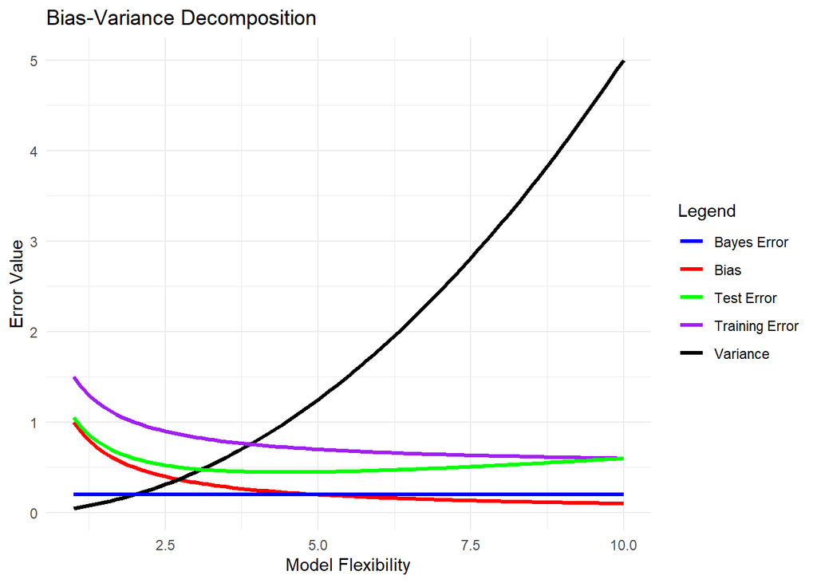

```r
# Load necessary libraries
library(ggplot2)

# Generate sample data for plotting
flexibility <- seq(1, 10, by = 0.1)  # Increasing flexibility from left to right

# Bias, Variance, and Error functions
bias <- 1 / flexibility
variance <- flexibility^2 / 20
training_error <- 1 / flexibility + 0.5
test_error <- (1 / flexibility) + (flexibility / 20)
bayes_error <- rep(0.2, length(flexibility))

# Create a data frame for plotting
df <- data.frame(
  flexibility = flexibility,
  bias = bias,
  variance = variance,
  training_error = training_error,
  test_error = test_error,
  bayes_error = bayes_error
)

# Plot the curves using ggplot2
ggplot(df, aes(x = flexibility)) +
  geom_line(aes(y = bias, color = "Bias"), linewidth = 1.2) +
  geom_line(aes(y = variance, color = "Variance"), linewidth = 1.2) +
  geom_line(aes(y = training_error, color = "Training Error"), linewidth = 1.2) +
  geom_line(aes(y = test_error, color = "Test Error"), linewidth = 1.2) +
  geom_line(aes(y = bayes_error, color = "Bayes Error"), linewidth = 1.2) +
  labs(
    title = "Bias-Variance Decomposition",
    x = "Model Flexibility",
    y = "Error Value",
    color = "Legend"
  ) +
  theme_minimal() +
  scale_color_manual(values = c("blue", "red", "green", "purple", "black"))
```

2. Explain why each of the five curves has the shape displayed in part (a).

Bias Curve: The bias decreases as model flexibility increases. Bias refers to the error introduced by approximating the true underlying relationship with a model that is too simple or constrained. For less flexible models the model is too rigid to capture the true relationship, so it has a large bias. As flexibility increases the model can better approximate the true function, so the bias decreases. Eventually, as flexibility continues to increase, the model becomes very complex, and bias approaches zero because the model can fit the training data very well.

Variance Curve: Variance increases as model flexibility increases. This measures how much the model’s predictions vary for different training sets. Less flexible models have less room for fluctuation, so the predictions are stable. Variance is low because the model’s predictions are not overly sensitive to the specific data. As the model flexibility increases, overfitting occurs to the training data, capturing noise. This leads to more variability in the model’s predictions on new data, causing an increase in variance. In extreme cases, very flexible models fit the training data perfectly, but their predictions can fluctuate wildly with small changes in the data.

Test Error Curve: The test error typically decreases, reaches a minimum, and then increases again as flexibility increases. This error reflects how well the model generalizes to new, unseen data. At low flexibility, the model is too simple to capture the underlying structure of the data, leading to high bias and poor generalization. The test error is high because the model cannot adapt to the true relationship. As flexibility increases, the model better captures the true patterns in the data, reducing both bias and test error. Initially, test error decreases as the model becomes more flexible and is able to generalize better. Beyond a certain point, the model becomes too flexible, which overfits the training data. This leads to an increase in test error.

Bayes Error Curve: The Bayes error is constant and does not change with flexibility. This is the lowest possible error that can be achieved, representing the inherent uncertainty in predicting the target variable, regardless of the model used. This error comes from factors like noise or the inherent randomness in the data.

## 3 ISL Exercise 2.4.4 (10% pts)

You will now think of some real-life applications for statistical learning.

1. Describe three real-life applications in which classification might be useful.Describe the response, as well as the predictors. Is the goal of each application inference or prediction? Explain your answer.

One useful example would be email spam detection. Having the ability to quickly sort through important emails and emails that will waste your time is a very practical for daily time management.

The response in this case would be if the email itself is classified as spam or not. This could be a binary classification 1 = spam, 0 = not spam.

The predictors in this case would be features in the emails themselves such as email address, certain keywords that advertisers use, metadata of the email itself (for example what time the email was sent).

The goal in this case is prediction. The model will be introduced to new emails constantly and will need to make a new prediction if the incoming email is classified as spam or not, based on prior data patterns or other parameters set by the model.

Another real-life application would be medical diagnosis. Certain cells in the human body could be classified as cancerous or benign. This is another example of binary classification.

The response in this case could be “cancerous” or benign”

Predictors would be various bio-statistical data pertaining to each patient such as age, blood levels, certain diets, concentration of exotic substances (radiation, carcinogenic chemicals)

The goal in this case would again be prediction. We are taking trained data from previous patients that had confirmed classified cases of cancer or not, and then applying that learned model to new patient data to predict if this new patient has cancer or not.

Last example given here could be in evaluating the effectiveness of a new drug.

The response would be whether or not a patient has improved or not improved.

Predictors in this case could be the dosage amount, overall health of the patients and other various demographics of the individuals that participate in the placebo (control) group vs that of the new drug (experimental) group.

This would be an example of an inference. We are taking in new data and making an inference on how statistically significant is the new drug performing. We are not making any predictive outcomes for individuals that take this drug.

2. Describe three real-life applications in which regression might be useful. Describe the response, as well as the predictors. Is the goal of each application inference or prediction? Explain your answer.

One example that was brought up in our lectures was advertising and the effect it has on sales.

The response here would the be sales figures themselves (how many units were sold, gross revenue).

The predictors in this case would be the amount spent on advertising, the advertising contents (what is being advertised and how), what time of the year it is (some products will sell better in the Winter for example), and the price of the product itself.

The goal here could depend on what we are trying to achieve. If we want to know how well a future product will do, we could be making a regression prediction. If we want to understand how well advertising expenditure effects previous products we would be doing a inference on that relationship (for example advertising revue vs sales revenue).

Another real-life example would be in housing prices.

The response would be the price of the house.

Predictors would be various features of that house such as number of bedrooms, square footage, location, or other special extensions of the house like a pool.

The goal here is prediction. We are aiming to predict the selling price of a house based on certain criteria.

Final example here would be for analyzing employee salaries.

The response would be the employee salary.

Predictors would be years of experience, education level, job position, location, an performance statistics if available.

The goal here is to infer how various factors influence an employee’s salary. We are aiming to understand the relationship between various factors instead of trying to make a specific prediction of an individual’s salary.

3. Describe three real-life applications in which cluster analysis might be useful.

One real-life example would be Image segmentation in computer vision projects. Often times we want to divide an image into different segments to help identify what is in a picture for example. There are a wide range of useful reasons to do this, one quick example is diagnosing diseases based of x-ray images or MRI scans by quickly sorting what is ordinary in the scan and what is abnormal.

We could apply cluster analysis to customers in marketing as well. Grouping customers into clusters based of purchasing behavior or demographics can help companies identify various types of customers such as frequent shoppers or one-time buyers. These companies can than look into specifics per group and adjust various tactics such as targeted marking.

Final example could be used for streaming services. Viewers of certain streaming services like Netflix can be clustered based on factors like minutes watched per day, total viewing sessions per week, or number of unique shows watched per month. These users can be clustered into high or low usage users and then the streaming companies can focus specific marketing strategies on the clusters that are more likely to return the most revenue.

## 4 ISL Exercise 2.4.10 (30% pts)

This exercise involves the Boston housing data set. (a) To begin, load in the Boston data set. The Boston data set is part of the ISLR2 library.

```r
library(tidyverse)

Boston <- read_csv("https://raw.githubusercontent.com/ucla-biostat-212a/2024winter/master/slides/data/Boston.csv", col_select = -1) %>%
  print(width = Inf)
```

```
# A tibble: 506 × 13
      crim    zn indus  chas   nox    rm   age   dis   rad   tax ptratio lstat
     <dbl> <dbl> <dbl> <dbl> <dbl> <dbl> <dbl> <dbl> <dbl> <dbl>   <dbl> <dbl>
 1 0.00632  18    2.31     0 0.538  6.58  65.2  4.09     1   296    15.3  4.98
 2 0.0273    0    7.07     0 0.469  6.42  78.9  4.97     2   242    17.8  9.14
 3 0.0273    0    7.07     0 0.469  7.18  61.1  4.97     2   242    17.8  4.03
 4 0.0324    0    2.18     0 0.458  7.00  45.8  6.06     3   222    18.7  2.94
 5 0.0690    0    2.18     0 0.458  7.15  54.2  6.06     3   222    18.7  5.33
 6 0.0298    0    2.18     0 0.458  6.43  58.7  6.06     3   222    18.7  5.21
 7 0.0883   12.5  7.87     0 0.524  6.01  66.6  5.56     5   311    15.2 12.4
 8 0.145    12.5  7.87     0 0.524  6.17  96.1  5.95     5   311    15.2 19.2
 9 0.211    12.5  7.87     0 0.524  5.63 100    6.08     5   311    15.2 29.9
10 0.170    12.5  7.87     0 0.524  6.00  85.9  6.59     5   311    15.2 17.1
    medv
   <dbl>
 1  24
 2  21.6
 3  34.7
 4  33.4
 5  36.2
 6  28.7
 7  22.9
 8  27.1
 9  16.5
10  18.9
# ℹ 496 more rows
```

Read about the data set:

```r
#Opens MASS documentation on this Boston dataset
??Boston
```

2. Make some pairwise scatterplots of the predictors (columns) in this data set. Describe your findings.

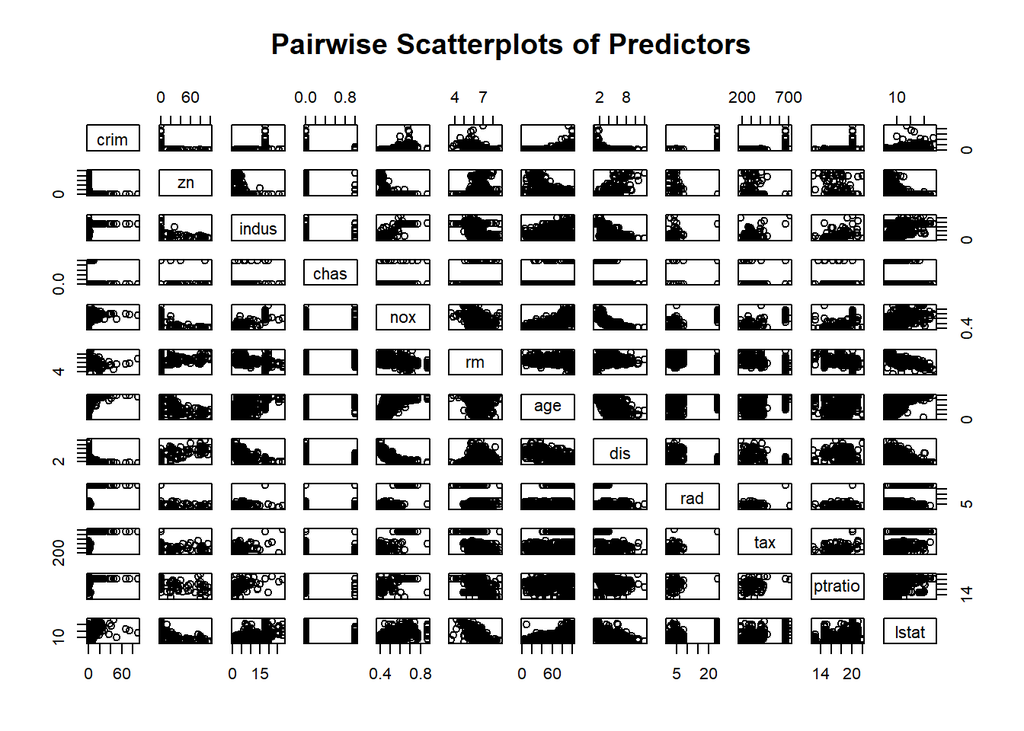

```r
#Create simple pairwise scatterplots, -13 to exclude medv which is our response
pairs(Boston[, -13], main = "Pairwise Scatterplots of Predictors")
```

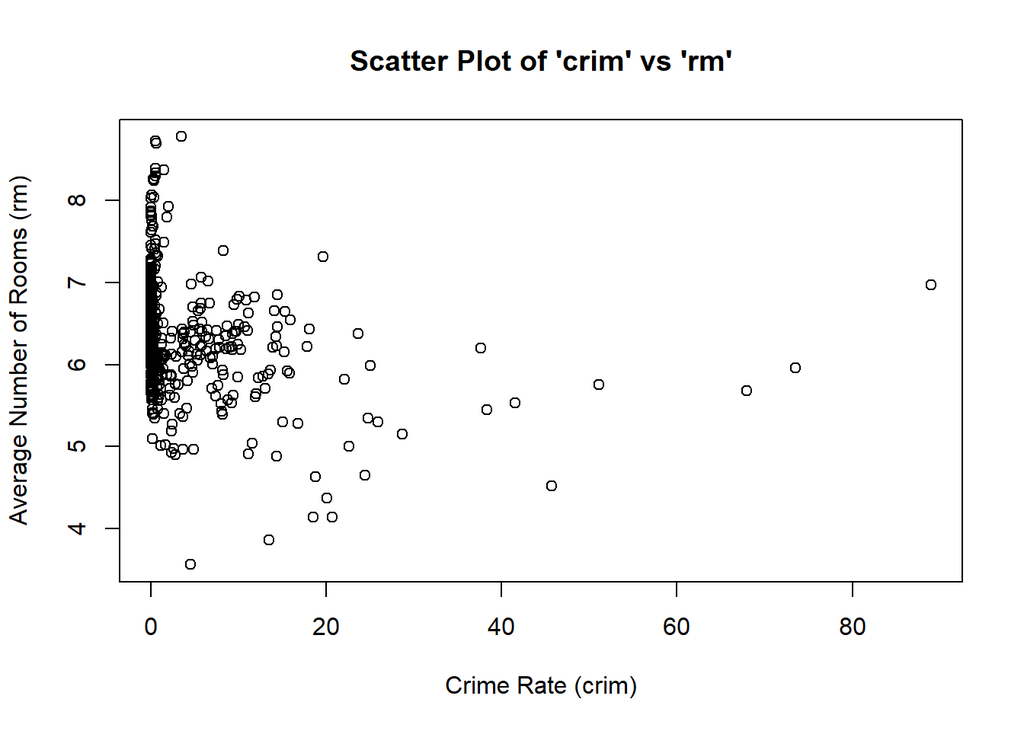

```r
#pairwise between distances to employment and crime
plot(Boston$crim, Boston$rm, main = "Scatter Plot of 'crim' vs 'rm'",
     xlab = "Crime Rate (crim)", ylab = "Average Number of Rooms (rm)")
```

[figure not shown]

```r
#pairwise between distances to employment and crime
plot(Boston$crim, Boston$dis, main = "Scatter Plot of 'crim' vs 'dis'",
     xlab = "Crime Rate (crim)", ylab = "Average Number of Rooms (rm)")
```

Some of the scatter plots suggest there is at least a positive correlation between certain predictors like dis and rm for predicting the median value of the house.

3. Are any of the predictors associated with per capita crime rate? If so, explain the relationship.

```r
# Calculate correlation between per capita crime rate by town and all other predictors
correlation_matrix <- cor(Boston)
cor_crim <- correlation_matrix["crim",-13]
cor_crim
```

```
       crim          zn       indus        chas         nox          rm
 1.00000000 -0.20046922  0.40658341 -0.05589158  0.42097171 -0.21924670
        age         dis         rad         tax     ptratio       lstat
 0.35273425 -0.37967009  0.62550515  0.58276431  0.28994558  0.45562148
```

[figure not shown]

```r
plot(Boston$crim, Boston$indus, main = "'Crime rate' vs 'non-retail business acres per town.'",
     xlab = "Crime Rate (crim)", ylab = "Average Number of Rooms (rm)")
```

From a simple correlation matrix we can see a few positive correlations with crime per capita. “indus” the proportion of non-retail business acres per town, “nox” which is nitrogen oxides concentration (parts per 10 million), “age” “rad” “tax” “ptratio” and “lstat” are other positively correlated predictors for crime in this dataset.

4. Do any of the census tracts of Boston appear to have particularly high crime rates? Tax rates? Pupil-teacher ratios?

Comment on the range of each predictor.

```r
# Compare the ranges of crime rate, tax rate, and pupil-teacher ratio
summary(Boston$crim)
```

```
    Min.  1st Qu.   Median     Mean  3rd Qu.     Max.
 0.00632  0.08204  0.25651  3.61352  3.67708 88.97620
```

```r
summary(Boston$tax)
```

```
   Min. 1st Qu.  Median    Mean 3rd Qu.    Max.
  187.0   279.0   330.0   408.2   666.0   711.0
```

```r
summary(Boston$ptratio)
```

```
   Min. 1st Qu.  Median    Mean 3rd Qu.    Max.
  12.60   17.40   19.05   18.46   20.20   22.00
```

```r
#looking at 75th percentile (these are normally considered outlines)
high_crim <- which(Boston$crim > quantile(Boston$crim, 0.75))
high_tax <- which(Boston$tax > quantile(Boston$tax, 0.75))
high_ptratio <- which(Boston$ptratio > quantile(Boston$ptratio, 0.75))

# Print the census tracts with extreme values
cat("Census tracts with high crime rates: ", high_crim, "\n")
```

[output not shown]

```r
cat("Census tracts with high tax rates: ", high_tax, "\n")
```

```
Census tracts with high tax rates:  489 490 491 492 493
```

```r
cat("Census tracts with high pupil-teacher ratios: ", high_ptratio, "\n")
```

```
Census tracts with high pupil-teacher ratios:  14 15 16 17 18 19 20 21 22 23 24 25 26 27 28 29 30 31 32 33 34 35 55 101 102 103 104 105 106 107 108 109 110 111 128 129 130 131 132 133 134 135 136 137 138 139 140 141 142 355 356 502 503 504 505 506
```

```r
cat("Range of Boston Crime: ", range(Boston$crim), "\n")
```

```
Range of Boston Crime:  0.00632 88.9762
```

```r
cat("Range of Boston Tax: ", range(Boston$tax), "\n")
```

```
Range of Boston Tax:  187 711
```

```r
cat("Range of Boston ptratio: ", range(Boston$ptratio), "\n")
```

```
Range of Boston ptratio:  12.6 22
```

The range of crime goes as low as almost zero (but never reaches zero) and the max is 88.9762 The range of taxes goes as low as 187 and as high as 711 The range of the ptratio value goes from 12.6 to 22

These ranges are widely different from each other, so analyzing these predictors needs to be done carefully.

5. How many of the census tracts in this data set bound the Charles river?

```r
# Count how many census tracts are bound by the Charles River
sum(Boston$chas == 1)
```

```
[1] 35
```

35 Census bound the Charles river.

6. What is the median pupil-teacher ratio among the towns in this data set?

```r
# Calculate the median pupil-teacher ratio
median(Boston$ptratio)
```

```
[1] 19.05
```

The median ratio is 19.05.

7. Which census tract of Boston has lowest median value of owner occupied homes?

```r
# Find the index of the census tract with the lowest median value of owner-occupied homes
lowest_medv_index <- which.min(Boston$medv)
# Display the details of the census tract with the lowest median value
Boston[lowest_medv_index, ]
```

```
# A tibble: 1 × 13
   crim    zn indus  chas   nox    rm   age   dis   rad   tax ptratio lstat
  <dbl> <dbl> <dbl> <dbl> <dbl> <dbl> <dbl> <dbl> <dbl> <dbl>   <dbl> <dbl>
1  38.4     0  18.1     0 0.693  5.45   100  1.49    24   666    20.2  30.6
# ℹ 1 more variable: medv <dbl>
```

Census tract 399 has the lowest median value (5).

What are the values of the other predictors for that census tract?

From the code printed we see the following values for each predictor:

crim: 38.3518 zn: 0 indus: 18.1 chas: 0 nox: 0.693 rm: 5.453 age: 100 dis: 1.4896 rad: 24 tax: 666 ptratio: 20.2 lstat: 30.59

How do those values compare to the overall ranges for those predictors?

```r
# Apply the range function to each predictor in the Boston dataset (excluding the target variable 'medv')
range_df <- sapply(Boston, range)
# Print the range of all predictors
range_df
```

```
         crim  zn indus chas   nox    rm   age     dis rad tax ptratio lstat
[1,]  0.00632   0  0.46    0 0.385 3.561   2.9  1.1296   1 187    12.6  1.73
[2,] 88.97620 100 27.74    1 0.871 8.780 100.0 12.1265  24 711    22.0 37.97
     medv
[1,]    5
[2,]   50
```

Comment on your findings.

8. In this data set, how many of the census tracts average more than seven rooms per dwelling? More than eight rooms per dwelling? Comment on the census tracts that average more than eight rooms per dwelling.

```r
# Count how many census tracts have more than 7 rooms per dwelling
more_than_seven_rooms <- sum(Boston$rm > 7)

# Print the result
more_than_seven_rooms
```

```
[1] 64
```

```r
# Count how many census tracts have more than 8 rooms per dwelling
more_than_eight_rooms <- sum(Boston$rm > 8)

# Print the result
more_than_eight_rooms
```

```
[1] 13
```

```r
# Subset the census tracts with more than 8 rooms per dwelling
more_than_eight_df <- Boston[Boston$rm > 8, ]

# View the subset of census tracts with more than 8 rooms
(more_than_eight_df)
```

```
# A tibble: 13 × 13
     crim    zn indus  chas   nox    rm   age   dis   rad   tax ptratio lstat
    <dbl> <dbl> <dbl> <dbl> <dbl> <dbl> <dbl> <dbl> <dbl> <dbl>   <dbl> <dbl>
 1 0.121      0  2.89     0 0.445  8.07  76    3.50     2   276    18    4.21
 2 1.52       0 19.6      1 0.605  8.38  93.9  2.16     5   403    14.7  3.32
 3 0.0201    95  2.68     0 0.416  8.03  31.9  5.12     4   224    14.7  2.88
 4 0.315      0  6.2      0 0.504  8.27  78.3  2.89     8   307    17.4  4.14
 5 0.527      0  6.2      0 0.504  8.72  83    2.89     8   307    17.4  4.63
 6 0.382      0  6.2      0 0.504  8.04  86.5  3.22     8   307    17.4  3.13
 7 0.575      0  6.2      0 0.507  8.34  73.3  3.84     8   307    17.4  2.47
 8 0.331      0  6.2      0 0.507  8.25  70.4  3.65     8   307    17.4  3.95
 9 0.369     22  5.86     0 0.431  8.26   8.4  8.91     7   330    19.1  3.54
10 0.612     20  3.97     0 0.647  8.70  86.9  1.80     5   264    13    5.12
11 0.520     20  3.97     0 0.647  8.40  91.5  2.29     5   264    13    5.91
12 0.578     20  3.97     0 0.575  8.30  67    2.42     5   264    13    7.44
13 3.47       0 18.1      1 0.718  8.78  82.9  1.90    24   666    20.2  5.29
# ℹ 1 more variable: medv <dbl>
```

64 census tracts average more than seven rooms. 13 average more than eight rooms.

## 5 ISL Exercise 3.7.3 (20% pts)

Suppose we have a data set with five predictors, X1 = GPA, X2 = IQ, X3 = Level (1 for College and 0 for High School), X4 = Interaction between GPA and IQ, and X5 = Interaction between GPA and Level. The response is starting salary after graduation (in thousands of dollars). Suppose we use least squares to ft the model, and get $β^0 = 50$, $β^1 = 20$, $β^2 = 0.07$, $β^3 = 35$, $β^4 = 0.01$, $β^5 = −10$.

2. Predict the salary of a college graduate with IQ of 110 and a GPA of 4.0.

$$Salary=50+20⋅GPA+0.07⋅IQ+35⋅Level+0.01⋅(GPA×IQ)+(−10)⋅(GPA×Level)$$
Plug in values
$$Level = 1, GPA = 4.0, IQ = 110$$
$$Salary=50+80+7.7+35+4.4−40=137.1$$

3. True or false: Since the coefficient for the GPA/IQ interaction term is very small, there is very little evidence of an interaction effect. Justify your answer.

False. We would need to perform a null-hypothesis test or report the standard error on this coefficient in order to evaluate how significant this value is.

## 6 ISL Exercise 3.7.15 (20% pts)

This problem involves the Boston data set, which we saw in the lab for this chapter. We will now try to predict per capita crime rate using the other variables in this data set. In other words, per capita crime rate is the response, and the other variables are the predictors.

1. For each predictor, ft a simple linear regression model to predict the response. Describe your results. In which of the models is there a statistically significant association between the predictor and the response? Create some plots to back up your assertions.

```r
# Get the list of predictors (exclude 'CRIM' from the dataset)
predictors <- setdiff(names(Boston), "crim")

# Loop through each predictor and fit the linear model
models <- lapply(predictors, function(predictor) {
  lm(crim ~ get(predictor), data = Boston)
})

# Create the scatter plot with the regression line

plot_list <- lapply(predictors, function(predictor) {
  ggplot(Boston, aes(x = .data[[predictor]], y = Boston$crim)) +
    geom_point() +  # scatter plot
    geom_smooth(method = "lm", se = FALSE, color = "blue") +  # regression line
    labs(title = paste("Crime Rate vs", predictor),
         x = predictor,
         y = "Per Capita Crime Rate (criim)") +
    theme_minimal()
})

model_summaries <- lapply(models, summary)
# Extract p-values from the model summaries
p_values <- sapply(model_summaries, function(model_summary) {
  coef(model_summary)[2, "Pr(>|t|)"]  # Extracting the p-value for the predictor (2nd row corresponds to predictor)
})

# Display p-values and check which predictors are significant
significant_predictors <- names(p_values)[p_values < 0.05]
cat("Statistically significant predictors are:", significant_predictors, "\n")
```

```
Statistically significant predictors are:
```

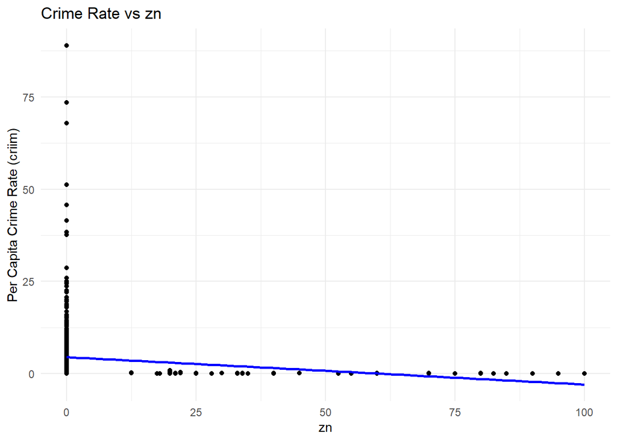

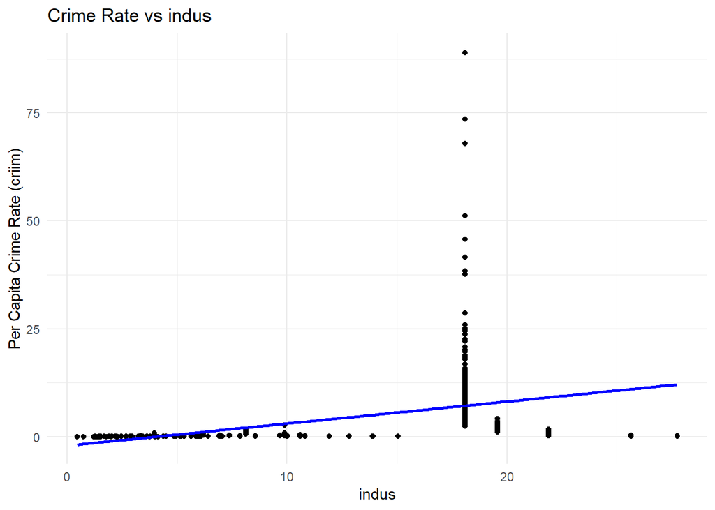

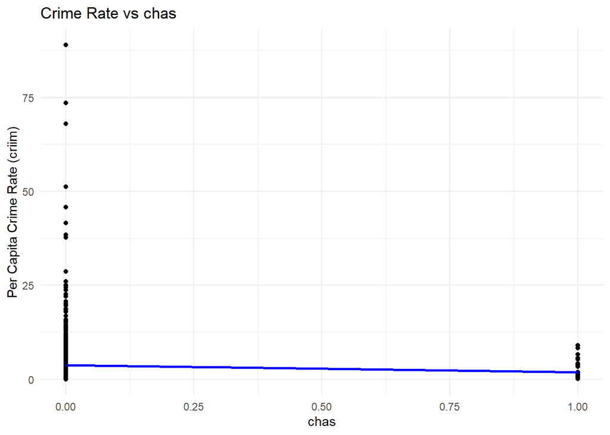

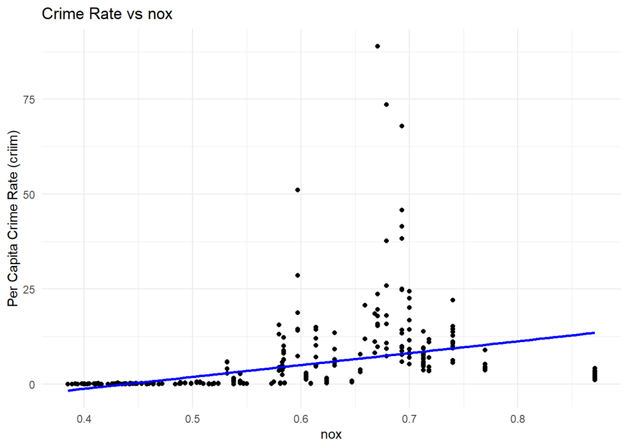

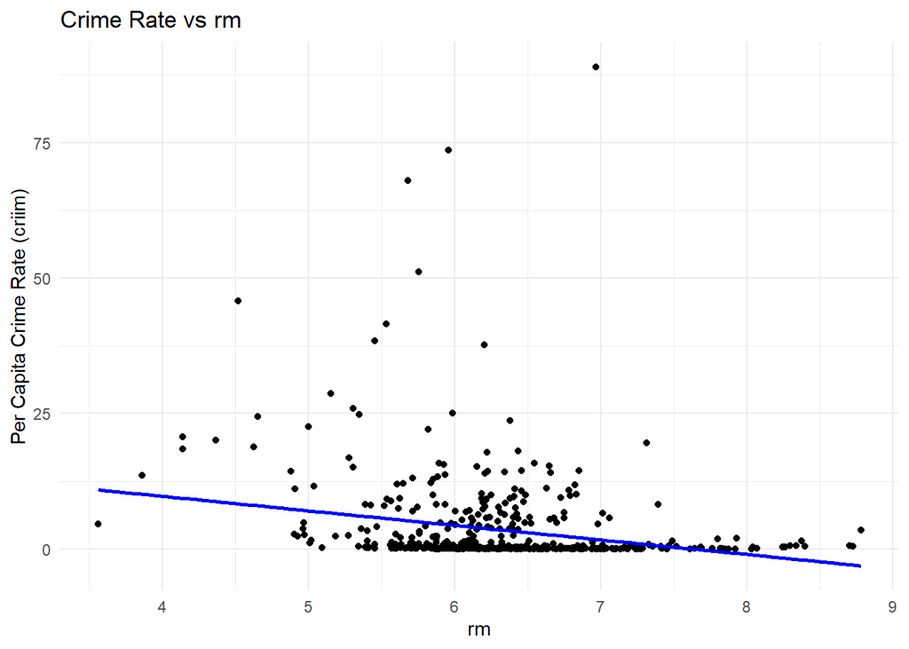

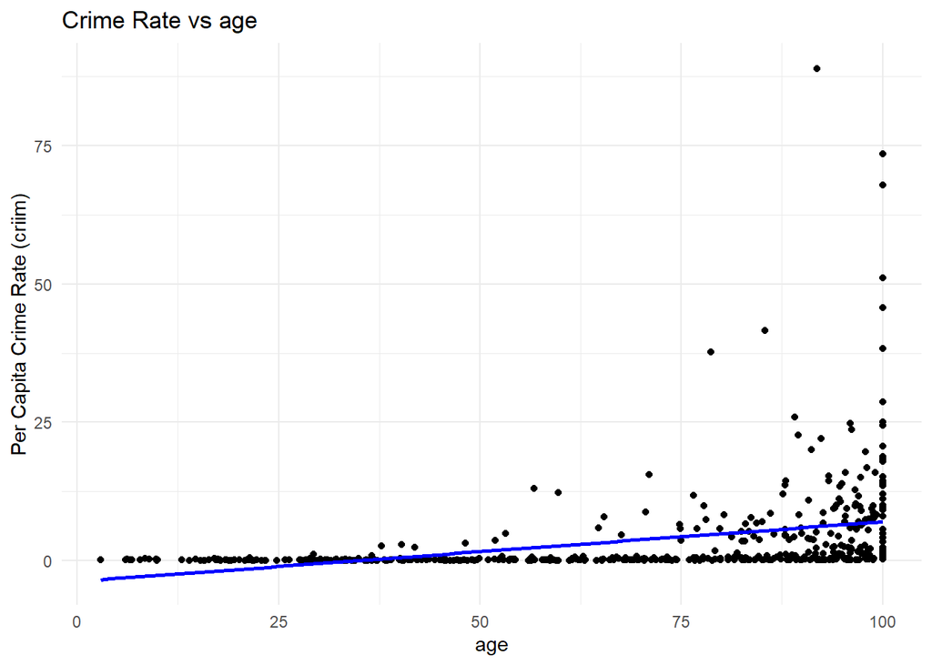

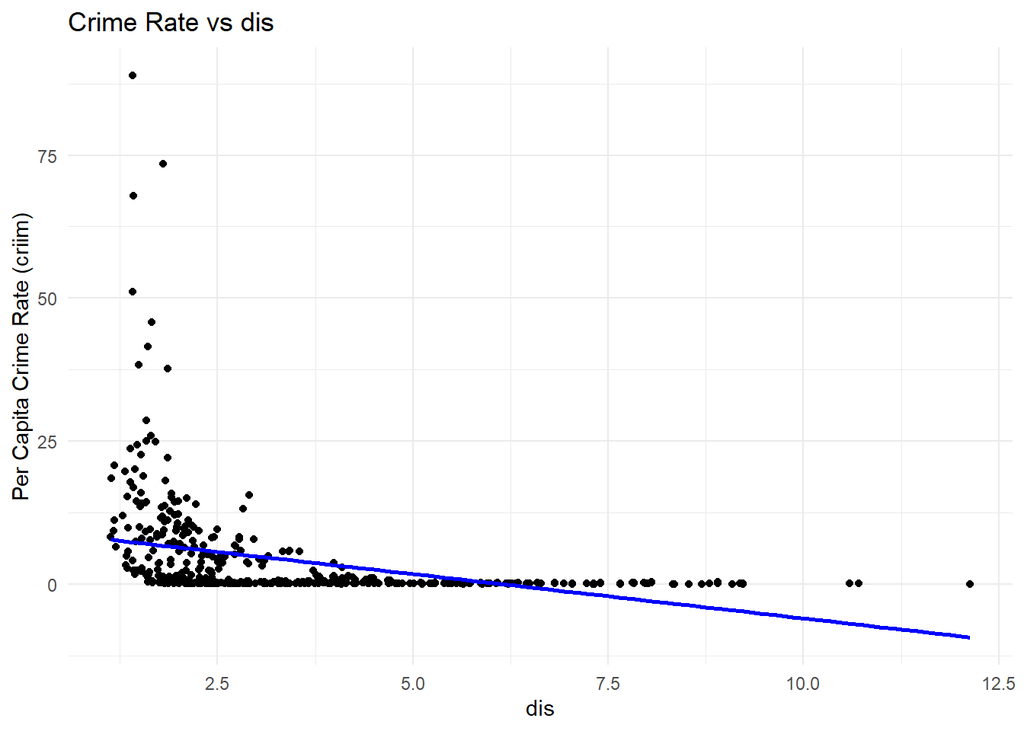

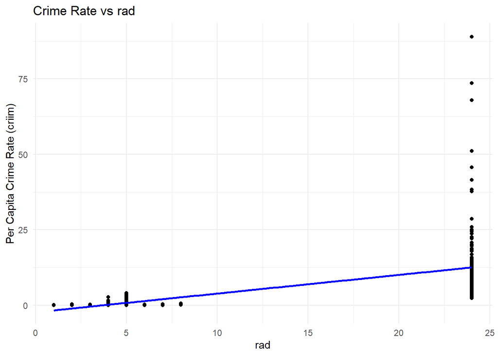

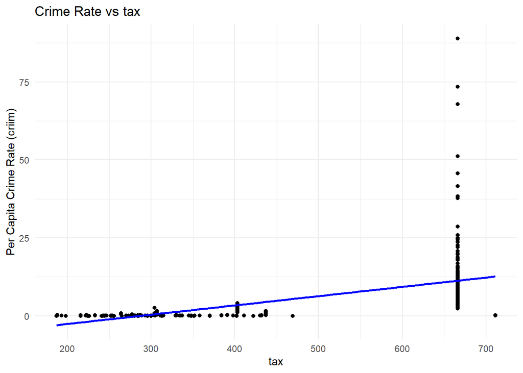

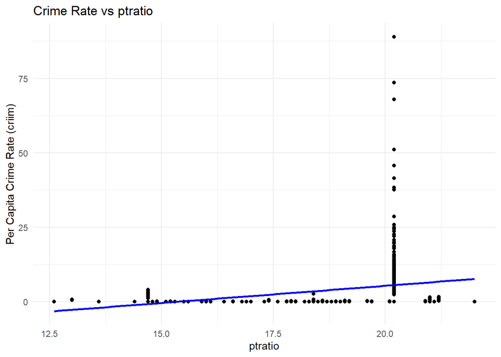

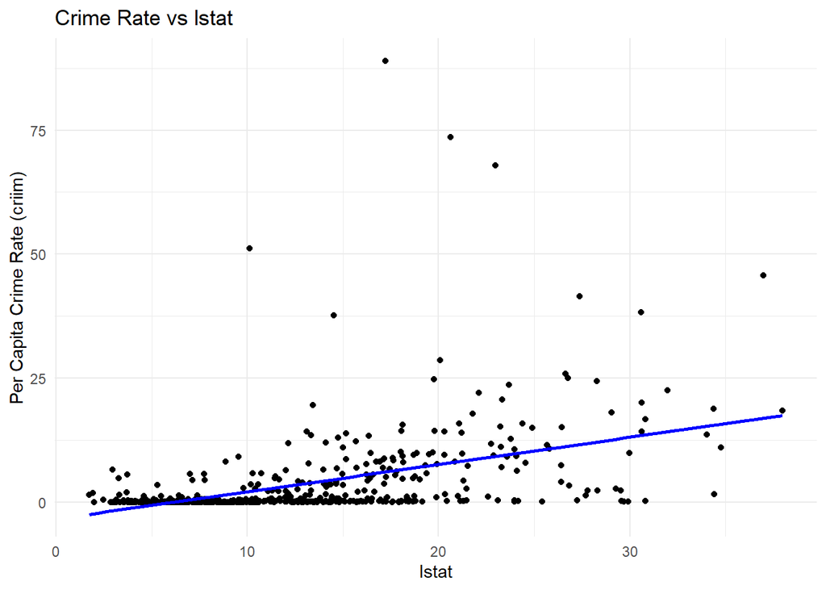

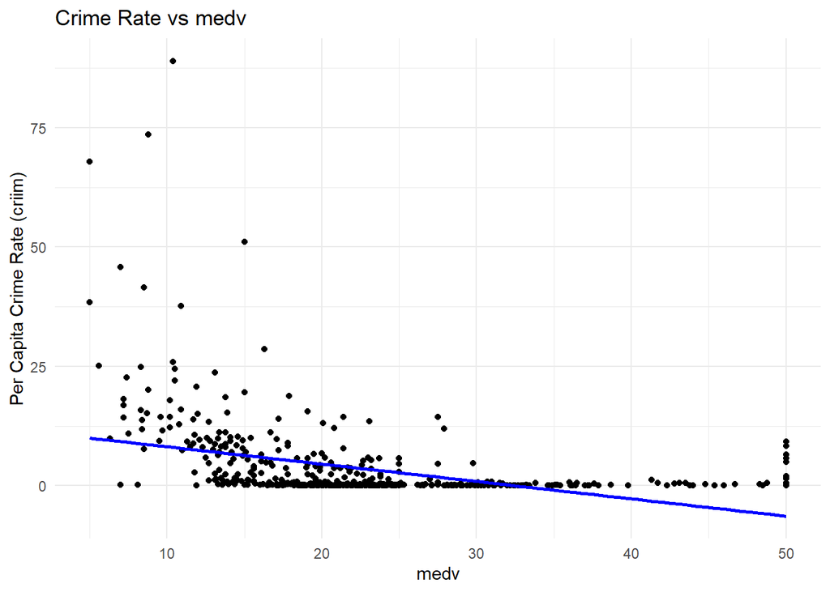

```r
# Print plots to check the result and display summaries for each model
print(plot_list)
```

```r
print(model_summaries)
```

```
[[1]]

Call:
lm(formula = crim ~ get(predictor), data = Boston)

Residuals:
   Min     1Q Median     3Q    Max
-4.429 -4.222 -2.620  1.250 84.523

Coefficients:
               Estimate Std. Error t value Pr(>|t|)
(Intercept)     4.45369    0.41722  10.675  < 2e-16 ***
get(predictor) -0.07393    0.01609  -4.594 5.51e-06 ***
---
Signif. codes:  0 '***' 0.001 '**' 0.01 '*' 0.05 '.' 0.1 ' ' 1

Residual standard error: 8.435 on 504 degrees of freedom
Multiple R-squared:  0.04019,   Adjusted R-squared:  0.03828
F-statistic:  21.1 on 1 and 504 DF,  p-value: 5.506e-06


[[2]]

Call:
lm(formula = crim ~ get(predictor), data = Boston)

Residuals:
    Min      1Q  Median      3Q     Max
-11.972  -2.698  -0.736   0.712  81.813

Coefficients:
               Estimate Std. Error t value Pr(>|t|)
(Intercept)    -2.06374    0.66723  -3.093  0.00209 **
get(predictor)  0.50978    0.05102   9.991  < 2e-16 ***
---
Signif. codes:  0 '***' 0.001 '**' 0.01 '*' 0.05 '.' 0.1 ' ' 1

Residual standard error: 7.866 on 504 degrees of freedom
Multiple R-squared:  0.1653,    Adjusted R-squared:  0.1637
F-statistic: 99.82 on 1 and 504 DF,  p-value: < 2.2e-16
```

[output cut: 195 more lines]

```

Residuals:
   Min     1Q Median     3Q    Max
-9.071 -4.022 -2.343  1.298 80.957

Coefficients:
               Estimate Std. Error t value Pr(>|t|)
(Intercept)    11.79654    0.93419   12.63   <2e-16 ***
get(predictor) -0.36316    0.03839   -9.46   <2e-16 ***
---
Signif. codes:  0 '***' 0.001 '**' 0.01 '*' 0.05 '.' 0.1 ' ' 1

Residual standard error: 7.934 on 504 degrees of freedom
Multiple R-squared:  0.1508,    Adjusted R-squared:  0.1491
F-statistic: 89.49 on 1 and 504 DF,  p-value: < 2.2e-16
```

2. Fit a multiple regression model to predict the response using all of the predictors. Describe your results. For which predictors can we reject the null hypothesis $H_0 : β_j = 0$?

```r
# Fit the multiple regression model using all predictors
multiple_model <- lm(crim ~ ., data = Boston)

# Display the summary of the model
summary(multiple_model)
```

```
Call:
lm(formula = crim ~ ., data = Boston)

Residuals:
   Min     1Q Median     3Q    Max
-8.534 -2.248 -0.348  1.087 73.923

Coefficients:
              Estimate Std. Error t value Pr(>|t|)
(Intercept) 13.7783938  7.0818258   1.946 0.052271 .
zn           0.0457100  0.0187903   2.433 0.015344 *
indus       -0.0583501  0.0836351  -0.698 0.485709
chas        -0.8253776  1.1833963  -0.697 0.485841
nox         -9.9575865  5.2898242  -1.882 0.060370 .
rm           0.6289107  0.6070924   1.036 0.300738
age         -0.0008483  0.0179482  -0.047 0.962323
dis         -1.0122467  0.2824676  -3.584 0.000373 ***
rad          0.6124653  0.0875358   6.997 8.59e-12 ***
tax         -0.0037756  0.0051723  -0.730 0.465757
ptratio     -0.3040728  0.1863598  -1.632 0.103393
lstat        0.1388006  0.0757213   1.833 0.067398 .
medv        -0.2200564  0.0598240  -3.678 0.000261 ***
---
Signif. codes:  0 '***' 0.001 '**' 0.01 '*' 0.05 '.' 0.1 ' ' 1

Residual standard error: 6.46 on 493 degrees of freedom
Multiple R-squared:  0.4493,    Adjusted R-squared:  0.4359
F-statistic: 33.52 on 12 and 493 DF,  p-value: < 2.2e-16
```

From this list of predictors we can reject the null for the following predictors: zn dis rad medv

3. How do your results from (a) compare to your results from (b)?

Create a plot displaying the univariate regression coefficients from (a) on the x-axis, and the multiple regression coefficients from (b) on the y-axis. That is, each predictor is displayed as a single point in the plot.

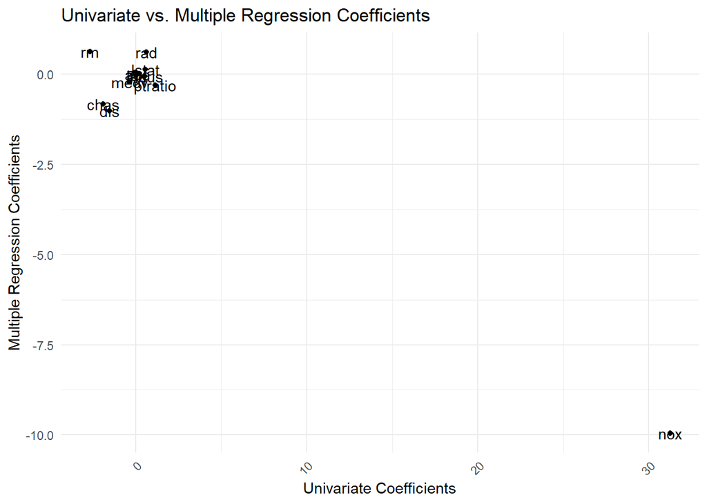

```r
# Fit the univariate regression models and extract coefficients
predictors <- setdiff(names(Boston), "crim")  # Exclude the response variable 'CRIM'

# Fit univariate models and extract coefficients
univariate_coefs <- sapply(predictors, function(predictor) {
  model <- lm(crim ~ get(predictor), data = Boston)
  coef(model)[2]  # Extract the coefficient for the predictor (ignoring the intercept)
})

#Fit the multiple regression model
multiple_model <- lm(crim ~ ., data = Boston)

# Extract the coefficients from the multiple regression model
multiple_coefs <- coef(multiple_model)[-1]  # Exclude the intercept

#Create a data frame for plotting
coef_data <- data.frame(
  predictor = predictors,
  univariate = univariate_coefs,
  multiple = multiple_coefs
)

# Create the plot
ggplot(coef_data, aes(x = univariate, y = multiple)) +
  geom_point() +  # Add points for each predictor
  geom_text(aes(label = predictor), hjust = 0.5, vjust = 0.5) +  # Add labels with predictor names
  labs(title = "Univariate vs. Multiple Regression Coefficients",
       x = "Univariate Coefficients",
       y = "Multiple Regression Coefficients") +
  theme_minimal() +
  theme(axis.text.x = element_text(angle = 45, hjust = 1))
```

Its coefficient in a simple linear regression model is shown on the x-axis, and its coefficient estimate in the multiple linear regression model is shown on the y-axis.

4. Is there evidence of non-linear association between any of the predictors and the response? To answer this question, for each predictor X, ft a model of the form $Y = β^0 + β^1X + β^2X_2 + β^3X_3 + ϵ$.

```r
# Get the list of predictors (exclude 'CRIM' from the dataset)
predictors <- setdiff(names(Boston), "crim")

# Fit a quadratic model for each predictor and extract coefficients
quadratic_models <- lapply(predictors, function(predictor) {
  lm(crim ~ get(predictor) + I(get(predictor)^2), data = Boston)
})

#Display summaries for each quadratic model to check the significance of the quadratic term
quadratic_summaries <- lapply(quadratic_models, summary)

# Print summaries of each model
quadratic_summaries
```

```
[[1]]

Call:
lm(formula = crim ~ get(predictor) + I(get(predictor)^2), data = Boston)

Residuals:
   Min     1Q Median     3Q    Max
-4.760 -4.553 -1.491  0.821 84.191

Coefficients:
                      Estimate Std. Error t value Pr(>|t|)
(Intercept)          4.7853138  0.4302223  11.123  < 2e-16 ***
get(predictor)      -0.2159497  0.0521941  -4.137 4.12e-05 ***
I(get(predictor)^2)  0.0019080  0.0006676   2.858  0.00444 **
---
Signif. codes:  0 '***' 0.001 '**' 0.01 '*' 0.05 '.' 0.1 ' ' 1

Residual standard error: 8.376 on 503 degrees of freedom
Multiple R-squared:  0.05553,   Adjusted R-squared:  0.05177
F-statistic: 14.79 on 2 and 503 DF,  p-value: 5.757e-07


[[2]]

Call:
lm(formula = crim ~ get(predictor) + I(get(predictor)^2), data = Boston)

Residuals:
   Min     1Q Median     3Q    Max
-7.530 -3.769 -1.069  1.354 81.462

Coefficients:
                     Estimate Std. Error t value Pr(>|t|)
(Intercept)         -4.849269   1.109293  -4.371 1.50e-05 ***
get(predictor)       1.189715   0.223173   5.331 1.48e-07 ***
I(get(predictor)^2) -0.027993   0.008949  -3.128  0.00186 **
---
Signif. codes:  0 '***' 0.001 '**' 0.01 '*' 0.05 '.' 0.1 ' ' 1

Residual standard error: 7.799 on 503 degrees of freedom
```

[output cut: 207 more lines]

```
Residuals:
    Min      1Q  Median      3Q     Max
-18.802  -3.127  -0.593   2.031  75.204

Coefficients:
                     Estimate Std. Error t value Pr(>|t|)
(Intercept)         31.969173   1.777610   17.98   <2e-16 ***
get(predictor)      -2.071441   0.137980  -15.01   <2e-16 ***
I(get(predictor)^2)  0.030938   0.002425   12.76   <2e-16 ***
---
Signif. codes:  0 '***' 0.001 '**' 0.01 '*' 0.05 '.' 0.1 ' ' 1

Residual standard error: 6.903 on 503 degrees of freedom
Multiple R-squared:  0.3584,    Adjusted R-squared:  0.3559
F-statistic: 140.5 on 2 and 503 DF,  p-value: < 2.2e-16
```

## 7 Bonus question (20% pts)

For multiple linear regression, show that $R^2$ is equal to the correlation between the response vector $\mathbf{y} = (y_1, \ldots, y_n)^T$ and the fitted values $\hat{\mathbf{y}} = (\hat y_1, \ldots, \hat y_n)^T$. That is
$$R^2 = 1 - \frac{\text{RSS}}{\text{TSS}} = [\operatorname{Cor}(\mathbf{y}, \hat{\mathbf{y}})]^2.$$

### 7.1 Definitions:

- **Total Sum of Squares (TSS):** This is the total variability in the response variable, which is defined as:
  $$\text{TSS} = \sum_{i=1}^{n} (y_i - \bar{y})^2$$
  where $\bar{y}$ is the mean of the response vector $\mathbf{y}$.
- **Residual Sum of Squares (RSS):** This is the variability in the residuals (the difference between the observed and the fitted values), defined as:
  $$\text{RSS} = \sum_{i=1}^{n} (y_i - \hat{y}_i)^2$$
  where $\hat{y}_i$ is the fitted value for the $i$-th observation.
- **Explained Sum of Squares (ESS):** This is the variability in the response that is explained by the fitted model. It is given by:
  $$\text{ESS} = \sum_{i=1}^{n} (\hat{y}_i - \bar{y})^2$$
  The total variability in $\mathbf{y}$ can be decomposed as:
  $$\text{TSS} = \text{ESS} + \text{RSS}$$
  Thus:
  $$R^2 = 1 - \frac{\text{RSS}}{\text{TSS}}$$
  This is the definition of $ R^2 $, the proportion of variance in $ $ that is explained by the fitted model.

### 7.2 Relationship Between Correlation and $R^2$

The square of the **correlation** between the response vector $\mathbf{y}$ and the fitted values $\hat{\mathbf{y}}$ is given by:
$$[\operatorname{Cor}(\mathbf{y}, \hat{\mathbf{y}})]^2 = \left( \frac{\text{Cov}(\mathbf{y}, \hat{\mathbf{y}})}{\sqrt{\text{Var}(\mathbf{y}) \cdot \text{Var}(\hat{\mathbf{y}})}} \right)^2$$
where:

- $\text{Cov}(\mathbf{y}, \hat{\mathbf{y}})$ is the covariance between $\mathbf{y}$ and $\hat{\mathbf{y}}$.
- $\text{Var}(\mathbf{y})$ is the variance of $\mathbf{y}$.
- $\text{Var}(\hat{\mathbf{y}})$ is the variance of the fitted values $\hat{\mathbf{y}}$.

### 7.3 Covariance Between $\mathbf{y}$ and $\hat{\mathbf{y}}$

The covariance between $\mathbf{y}$ and $\hat{\mathbf{y}}$ can be computed as:
$$\text{Cov}(\mathbf{y}, \hat{\mathbf{y}}) = \frac{1}{n} \sum_{i=1}^{n} (y_i - \bar{y})(\hat{y}_i - \bar{\hat{y}})$$
where $\bar{\hat{y}}$ is the mean of the fitted values. However, since the model is linear, $\hat{\mathbf{y}}$ has the same mean as $\mathbf{y}$.

Thus, the covariance simplifies to:
$$\text{Cov}(\mathbf{y}, \hat{\mathbf{y}}) = \frac{1}{n} \sum_{i=1}^{n} (y_i - \bar{y})(\hat{y}_i - \bar{y})$$
which is just the **explained sum of squares (ESS)** divided by $n$:
$$\text{Cov}(\mathbf{y}, \hat{\mathbf{y}}) = \frac{\text{ESS}}{n}$$

We compute the variances of $\mathbf{y}$ and $\hat{\mathbf{y}}$:

- The variance of $\mathbf{y}$ is:
  $$\text{Var}(\mathbf{y}) = \frac{1}{n} \sum_{i=1}^{n} (y_i - \bar{y})^2 = \frac{\text{TSS}}{n}$$
- The variance of $\hat{\mathbf{y}}$ is:
  $$\text{Var}(\hat{\mathbf{y}}) = \frac{1}{n} \sum_{i=1}^{n} (\hat{y}_i - \bar{y})^2 = \frac{\text{ESS}}{n}$$

### 7.4 Correlation Between $\mathbf{y}$ and $\hat{\mathbf{y}}$

Now we can calculate the correlation:
$$[\operatorname{Cor}(\mathbf{y}, \hat{\mathbf{y}})]^2 = \left( \frac{\text{Cov}(\mathbf{y}, \hat{\mathbf{y}})}{\sqrt{\text{Var}(\mathbf{y}) \cdot \text{Var}(\hat{\mathbf{y}})}} \right)^2$$
Substituting in the expressions for covariance and variance:
$$[\operatorname{Cor}(\mathbf{y}, \hat{\mathbf{y}})]^2 = \left( \frac{\frac{\text{ESS}}{n}}{\sqrt{\frac{\text{TSS}}{n} \cdot \frac{\text{ESS}}{n}}} \right)^2$$
Simplifying:
$$[\operatorname{Cor}(\mathbf{y}, \hat{\mathbf{y}})]^2 = \frac{\text{ESS}^2}{\text{TSS} \cdot \text{ESS}} = \frac{\text{ESS}}{\text{TSS}} = 1 - \frac{\text{RSS}}{\text{TSS}}$$
Thus, we have shown that:
$$R^2 = [\operatorname{Cor}(\mathbf{y}, \hat{\mathbf{y}})]^2 = 1 - \frac{\text{RSS}}{\text{TSS}}$$